Chapter 2

Linear Algebra

Linear algebra is a branch of mathematics that is widely used throughout science

and engineering. Yet because linear algebra is a form of continuous rather than

discrete mathematics, many computer scientists have little experience with it. A

good understanding of linear algebra is essential for understanding and working

with many machine learning algorithms, especially deep learning algorithms. We

therefore precede our introduction to deep learning with a focused presentation of

the key linear algebra prerequisites.

If you are already familiar with linear algebra, feel free to skip this chapter. If

you have previous experience with these concepts but need a detailed reference

sheet to review key formulas, we recommend The Matrix Cookbook (Petersen and

Pedersen, 2006). If you have had no exposure at all to linear algebra, this chapter

will teach you enough to read this book, but we highly recommend that you also

consult another resource focused exclusively on teaching linear algebra, such as

Shilov (1977). This chapter completely omits many important linear algebra topics

that are not essential for understanding deep learning.

2.1 Scalars, Vectors, Matrices and Tensors

The study of linear algebra involves several types of mathematical objects:

• Scalars

: A scalar is just a single number, in contrast to most of the other

objects studied in linear algebra, which are usually arrays of multiple numbers.

We write scalars in italics. We usually give scalars lowercase variable names.

When we introduce them, we specify what kind of number they are. For

29

CHAPTER 2. LINEAR ALGEBRA

example, we might say “Let

s ∈ R

be the slope of the line,” while deﬁning a

real-valued scalar, or “Let

n ∈ N

be the number of units,” while deﬁning a

natural number scalar.

• Vectors

: A vector is an array of numbers. The numbers are arranged in

order. We can identify each individual number by its index in that ordering.

Typically we give vectors lowercase names in bold typeface, such as

x

. The

elements of the vector are identiﬁed by writing its name in italic typeface,

with a subscript. The ﬁrst element of

x

is

x

1

, the second element is

x

2

, and

so on. We also need to say what kind of numbers are stored in the vector. If

each element is in

R

, and the vector has

n

elements, then the vector lies in

the set formed by taking the Cartesian product of

R n

times, denoted as

R

n

.

When we need to explicitly identify the elements of a vector, we write them

as a column enclosed in square brackets:

x =

x

1

x

2

.

.

.

x

n

. (2.1)

We can think of vectors as identifying points in space, with each element

giving the coordinate along a diﬀerent axis.

Sometimes we need to index a set of elements of a vector. In this case, we

deﬁne a set containing the indices and write the set as a subscript. For

example, to access

x

1

,

x

3

and

x

6

, we deﬁne the set

S

=

{

1

,

3

,

6

}

and write

x

S

. We use the

−

sign to index the complement of a set. For example

x

−1

is

the vector containing all elements of

x

except for

x

1

, and

x

−S

is the vector

containing all elements of x except for x

1

, x

3

and x

6

.

• Matrices

: A matrix is a 2-D array of numbers, so each element is identiﬁed

by two indices instead of just one. We usually give matrices uppercase

variable names with bold typeface, such as

A

. If a real-valued matrix

A

has

a height of

m

and a width of

n

, then we say that

A ∈ R

m×n

. We usually

identify the elements of a matrix using its name in italic but not bold font,

and the indices are listed with separating commas. For example,

A

1,1

is the

upper left entry of

A

and

A

m,n

is the bottom right entry. We can identify

all the numbers with vertical coordinate

i

by writing a “:” for the horizontal

coordinate. For example,

A

i,:

denotes the horizontal cross section of

A

with

vertical coordinate

i

. This is known as the

i

-th

row

of

A

. Likewise,

A

:,i

is

30

[figure not shown]

CHAPTER 2. LINEAR ALGEBRA

the i-th column of A. When we need to explicitly identify the elements of

a matrix, we write them as an array enclosed in square brackets:

A

1,1

A

1,2

A

2,1

A

2,2

. (2.2)

Sometimes we may need to index matrix-valued expressions that are not just

a single letter. In this case, we use subscripts after the expression but do not

convert anything to lowercase. For example,

f

(

A

)

i,j

gives element (

i, j

) of

the matrix computed by applying the function f to A.

• Tensors

: In some cases we will need an array with more than two axes.

In the general case, an array of numbers arranged on a regular grid with a

variable number of axes is known as a tensor. We denote a tensor named “A”

with this typeface:

A

. We identify the element of

A

at coordinates (

i, j, k

)

by writing A

i,j,k

.

One important operation on matrices is the

transpose

. The transpose of a

matrix is the mirror image of the matrix across a diagonal line, called the

main

diagonal

, running down and to the right, starting from its upper left corner. See

ﬁgure 2.1 for a graphical depiction of this operation. We denote the transpose of a

matrix A as A

, and it is deﬁned such that

(A

)

i,j

= A

j,i

. (2.3)

Vectors can be thought of as matrices that contain only one column. The

transpose of a vector is therefore a matrix with only one row. Sometimes we

A =

A

1,1

A

1,2

A

2,1

A

2,2

A

3,1

A

3,2

⇒ A

=

A

1,1

A

2,1

A

3,1

A

1,2

A

2,2

A

3,2

Figure 2.1: The transpose of the matrix can be thought of as a mirror image across the

main diagonal.

31

CHAPTER 2. LINEAR ALGEBRA

deﬁne a vector by writing out its elements in the text inline as a row matrix, then

using the transpose operator to turn it into a standard column vector, for example

x = [x

1

, x

2

, x

3

]

.

A scalar can be thought of as a matrix with only a single entry. From this, we

can see that a scalar is its own transpose: a = a

.

We can add matrices to each other, as long as they have the same shape, just

by adding their corresponding elements: C = A + B where C

i,j

= A

i,j

+ B

i,j

.

We can also add a scalar to a matrix or multiply a matrix by a scalar, just

by performing that operation on each element of a matrix:

D

=

a · B

+

c

where

D

i,j

= a · B

i,j

+ c.

In the context of deep learning, we also use some less conventional notation. We

allow the addition of a matrix and a vector, yielding another matrix:

C

=

A

+

b

,

where

C

i,j

=

A

i,j

+

b

j

. In other words, the vector

b

is added to each row of the

matrix. This shorthand eliminates the need to deﬁne a matrix with

b

copied into

each row before doing the addition. This implicit copying of

b

to many locations

is called broadcasting.

2.2 Multiplying Matrices and Vectors

One of the most important operations involving matrices is multiplication of two

matrices. The

matrix product

of matrices

A

and

B

is a third matrix

C

. In

order for this product to be deﬁned,

A

must have the same number of columns as

B

has rows. If

A

is of shape

m × n

and

B

is of shape

n × p

, then

C

is of shape

m × p

. We can write the matrix product just by placing two or more matrices

together, for example,

C = AB. (2.4)

The product operation is deﬁned by

C

i,j

=

k

A

i,k

B

k,j

. (2.5)

Note that the standard product of two matrices is not just a matrix containing

the product of the individual elements. Such an operation exists and is called the

element-wise product, or Hadamard product, and is denoted as A B.

The

dot product

between two vectors

x

and

y

of the same dimensionality

is the matrix product

x

y

. We can think of the matrix product

C

=

AB

as

computing C

i,j

as the dot product between row i of A and column j of B.

32

CHAPTER 2. LINEAR ALGEBRA

Matrix product operations have many useful properties that make mathematical

analysis of matrices more convenient. For example, matrix multiplication is

distributive:

A(B + C) = AB + AC. (2.6)

It is also associative:

A(BC) = (AB)C. (2.7)

Matrix multiplication is not commutative (the condition

AB

=

BA

does not

always hold), unlike scalar multiplication. However, the dot product between two

vectors is commutative:

x

y = y

x. (2.8)

The transpose of a matrix product has a simple form:

(AB)

= B

A

. (2.9)

This enables us to demonstrate equation 2.8 by exploiting the fact that the value

of such a product is a scalar and therefore equal to its own transpose:

x

y =

x

y

= y

x. (2.10)

Since the focus of this textbook is not linear algebra, we do not attempt to

develop a comprehensive list of useful properties of the matrix product here, but

the reader should be aware that many more exist.

We now know enough linear algebra notation to write down a system of linear

equations:

Ax = b (2.11)

where

A ∈ R

m×n

is a known matrix,

b ∈ R

m

is a known vector, and

x ∈ R

n

is a

vector of unknown variables we would like to solve for. Each element

x

i

of

x

is one

of these unknown variables. Each row of

A

and each element of

b

provide another

constraint. We can rewrite equation 2.11 as

A

1,:

x = b

1

(2.12)

A

2,:

x = b

2

(2.13)

. . . (2.14)

A

m,:

x = b

m

(2.15)

or even more explicitly as

A

1,1

x

1

+ A

1,2

x

2

+ ··· + A

1,n

x

n

= b

1

(2.16)

33

CHAPTER 2. LINEAR ALGEBRA

A

2,1

x

1

+ A

2,2

x

2

+ ··· + A

2,n

x

n

= b

2

(2.17)

. . . (2.18)

A

m,1

x

1

+ A

m,2

x

2

+ ··· + A

m,n

x

n

= b

m

. (2.19)

Matrix-vector product notation provides a more compact representation for

equations of this form.

2.3 Identity and Inverse Matrices

Linear algebra oﬀers a powerful tool called

matrix inversion

that enables us to

analytically solve equation 2.11 for many values of A.

To describe matrix inversion, we ﬁrst need to deﬁne the concept of an

identity

matrix

. An identity matrix is a matrix that does not change any vector when we

multiply that vector by that matrix. We denote the identity matrix that preserves

n-dimensional vectors as I

n

. Formally, I

n

∈ R

n×n

, and

∀x ∈ R

n

, I

n

x = x. (2.20)

The structure of the identity matrix is simple: all the entries along the main

diagonal are 1, while all the other entries are zero. See ﬁgure 2.2 for an example.

The

matrix inverse

of

A

is denoted as

A

−1

, and it is deﬁned as the matrix

such that

A

−1

A = I

n

. (2.21)

We can now solve equation 2.11 using the following steps:

Ax = b (2.22)

A

−1

Ax = A

−1

b (2.23)

I

n

x = A

−1

b (2.24)

1 0 0

0 1 0

0 0 1

Figure 2.2: Example identity matrix: This is I

3

.

34

CHAPTER 2. LINEAR ALGEBRA

x = A

−1

b. (2.25)

Of course, this process depends on it being possible to ﬁnd

A

−1

. We discuss

the conditions for the existence of A

−1

in the following section.

When

A

−1

exists, several diﬀerent algorithms can ﬁnd it in closed form. In

theory, the same inverse matrix can then be used to solve the equation many times

for diﬀerent values of

b

.

A

−1

is primarily useful as a theoretical tool, however, and

should not actually be used in practice for most software applications. Because

A

−1

can be represented with only limited precision on a digital computer, algorithms

that make use of the value of b can usually obtain more accurate estimates of x.

2.4 Linear Dependence and Span

For

A

−1

to exist, equation 2.11 must have exactly one solution for every value of

b. It is also possible for the system of equations to have no solutions or inﬁnitely

many solutions for some values of

b

. It is not possible, however, to have more than

one but less than inﬁnitely many solutions for a particular

b

; if both

x

and

y

are

solutions, then

z = αx + (1 −α)y (2.26)

is also a solution for any real α.

To analyze how many solutions the equation has, think of the columns of

A

as

specifying diﬀerent directions we can travel in from the

origin

(the point speciﬁed

by the vector of all zeros), then determine how many ways there are of reaching

b

.

In this view, each element of

x

speciﬁes how far we should travel in each of these

directions, with x

i

specifying how far to move in the direction of column i:

Ax =

i

x

i

A

:,i

. (2.27)

In general, this kind of operation is called a

linear combination

. Formally, a

linear combination of some set of vectors

{v

(1)

, . . . , v

(n)

}

is given by multiplying

each vector v

(i)

by a corresponding scalar coeﬃcient and adding the results:

i

c

i

v

(i)

. (2.28)

The

span

of a set of vectors is the set of all points obtainable by linear combination

of the original vectors.

35

CHAPTER 2. LINEAR ALGEBRA

Determining whether

Ax

=

b

has a solution thus amounts to testing whether

b

is in the span of the columns of

A

. This particular span is known as the

column

space, or the range, of A.

In order for the system

Ax

=

b

to have a solution for all values of

b ∈ R

m

,

we therefore require that the column space of

A

be all of

R

m

. If any point in

R

m

is excluded from the column space, that point is a potential value of

b

that has

no solution. The requirement that the column space of

A

be all of

R

m

implies

immediately that

A

must have at least

m

columns, that is,

n ≥ m

. Otherwise, the

dimensionality of the column space would be less than

m

. For example, consider a

3

×

2 matrix. The target

b

is 3-D, but

x

is only 2-D, so modifying the value of

x

at best enables us to trace out a 2-D plane within

R

3

. The equation has a solution

if and only if b lies on that plane.

Having

n ≥ m

is only a necessary condition for every point to have a solution.

It is not a suﬃcient condition, because it is possible for some of the columns to

be redundant. Consider a 2

×

2 matrix where both of the columns are identical.

This has the same column space as a 2

×

1 matrix containing only one copy of the

replicated column. In other words, the column space is still just a line and fails to

encompass all of R

2

, even though there are two columns.

Formally, this kind of redundancy is known as

linear dependence

. A set of

vectors is

linearly independent

if no vector in the set is a linear combination

of the other vectors. If we add a vector to a set that is a linear combination of

the other vectors in the set, the new vector does not add any points to the set’s

span. This means that for the column space of the matrix to encompass all of

R

m

,

the matrix must contain at least one set of

m

linearly independent columns. This

condition is both necessary and suﬃcient for equation 2.11 to have a solution for

every value of

b

. Note that the requirement is for a set to have exactly

m

linearly

independent columns, not at least

m

. No set of

m

-dimensional vectors can have

more than

m

mutually linearly independent columns, but a matrix with more than

m columns may have more than one such set.

For the matrix to have an inverse, we additionally need to ensure that equa-

tion 2.11 has at most one solution for each value of

b

. To do so, we need to make

certain that the matrix has at most

m

columns. Otherwise there is more than one

way of parametrizing each solution.

Together, this means that the matrix must be

square

, that is, we require that

m

=

n

and that all the columns be linearly independent. A square matrix with

linearly dependent columns is known as singular.

If

A

is not square or is square but singular, solving the equation is still possible,

but we cannot use the method of matrix inversion to ﬁnd the solution.

36

[figure not shown]

CHAPTER 2. LINEAR ALGEBRA

So far we have discussed matrix inverses as being multiplied on the left. It is

also possible to deﬁne an inverse that is multiplied on the right:

AA

−1

= I. (2.29)

For square matrices, the left inverse and right inverse are equal.

2.5 Norms

Sometimes we need to measure the size of a vector. In machine learning, we usually

measure the size of vectors using a function called a

norm

. Formally, the

L

p

norm

is given by

||x||

p

=

i

|x

i

|

p

1

p

(2.30)

for p ∈ R, p ≥ 1.

Norms, including the

L

p

norm, are functions mapping vectors to non-negative

values. On an intuitive level, the norm of a vector

x

measures the distance from

the origin to the point

x

. More rigorously, a norm is any function

f

that satisﬁes

the following properties:

• f (x) = 0 ⇒ x = 0

• f (x + y) ≤ f (x) + f(y) (the triangle inequality)

• ∀α ∈ R, f(αx) = |α|f(x)

The

L

2

norm, with

p

= 2, is known as the

Euclidean norm

, which is simply

the Euclidean distance from the origin to the point identiﬁed by

x

. The

L

2

norm

is used so frequently in machine learning that it is often denoted simply as

||x||

,

with the subscript 2 omitted. It is also common to measure the size of a vector

using the squared L

2

norm, which can be calculated simply as x

x.

The squared

L

2

norm is more convenient to work with mathematically and

computationally than the

L

2

norm itself. For example, each derivative of the

squared

L

2

norm with respect to each element of

x

depends only on the corre-

sponding element of

x

, while all the derivatives of the

L

2

norm depend on the

entire vector. In many contexts, the squared

L

2

norm may be undesirable because

it increases very slowly near the origin. In several machine learning applications, it

is important to discriminate between elements that are exactly zero and elements

that are small but nonzero. In these cases, we turn to a function that grows at the

37

[figure not shown]

CHAPTER 2. LINEAR ALGEBRA

same rate in all locations, but that retains mathematical simplicity: the

L

1

norm.

The L

1

norm may be simpliﬁed to

||x||

1

=

i

|x

i

|. (2.31)

The L

1

norm is commonly used in machine learning when the diﬀerence between

zero and nonzero elements is very important. Every time an element of

x

moves

away from 0 by , the L

1

norm increases by .

We sometimes measure the size of the vector by counting its number of nonzero

elements. Some authors refer to this function as the “

L

0

norm,” but this is incorrect

terminology. The number of nonzero entries in a vector is not a norm, because

scaling the vector by

α

does not change the number of nonzero entries. The

L

1

norm is often used as a substitute for the number of nonzero entries.

One other norm that commonly arises in machine learning is the

L

∞

norm,

also known as the

max norm

. This norm simpliﬁes to the absolute value of the

element with the largest magnitude in the vector,

||x||

∞

= max

i

|x

i

|. (2.32)

Sometimes we may also wish to measure the size of a matrix. In the context

of deep learning, the most common way to do this is with the otherwise obscure

Frobenius norm:

||A||

F

=

i,j

A

2

i,j

, (2.33)

which is analogous to the L

2

norm of a vector.

The dot product of two vectors can be rewritten in terms of norms. Speciﬁcally,

x

y = ||x||

2

||y||

2

cos θ, (2.34)

where θ is the angle between x and y.

2.6 Special Kinds of Matrices and Vectors

Some special kinds of matrices and vectors are particularly useful.

Diagonal

matrices consist mostly of zeros and have nonzero entries only along

the main diagonal. Formally, a matrix

D

is diagonal if and only if

D

i,j

= 0 for

all

i

=

j

. We have already seen one example of a diagonal matrix: the identity

38

CHAPTER 2. LINEAR ALGEBRA

matrix, where all the diagonal entries are 1. We write

diag

(

v

) to denote a square

diagonal matrix whose diagonal entries are given by the entries of the vector

v

.

Diagonal matrices are of interest in part because multiplying by a diagonal matrix

is computationally eﬃcient. To compute

diag

(

v

)

x

, we only need to scale each

element

x

i

by

v

i

. In other words,

diag

(

v

)

x

=

v  x

. Inverting a square diagonal

matrix is also eﬃcient. The inverse exists only if every diagonal entry is nonzero,

and in that case,

diag

(

v

)

−1

=

diag

([1

/v

1

, . . . ,

1

/v

n

]

). In many cases, we may

derive some general machine learning algorithm in terms of arbitrary matrices

but obtain a less expensive (and less descriptive) algorithm by restricting some

matrices to be diagonal.

Not all diagonal matrices need be square. It is possible to construct a rectangular

diagonal matrix. Nonsquare diagonal matrices do not have inverses, but we can

still multiply by them cheaply. For a nonsquare diagonal matrix

D

, the product

Dx

will involve scaling each element of

x

and either concatenating some zeros to

the result, if

D

is taller than it is wide, or discarding some of the last elements of

the vector, if D is wider than it is tall.

A symmetric matrix is any matrix that is equal to its own transpose:

A = A

. (2.35)

Symmetric matrices often arise when the entries are generated by some function of

two arguments that does not depend on the order of the arguments. For example,

if

A

is a matrix of distance measurements, with

A

i,j

giving the distance from point

i to point j, then A

i,j

= A

j,i

because distance functions are symmetric.

A unit vector is a vector with unit norm:

||x||

2

= 1. (2.36)

A vector

x

and a vector

y

are

orthogonal

to each other if

x

y

= 0. If both

vectors have nonzero norm, this means that they are at a 90 degree angle to each

other. In

R

n

, at most

n

vectors may be mutually orthogonal with nonzero norm.

If the vectors not only are orthogonal but also have unit norm, we call them

orthonormal.

An

orthogonal matrix

is a square matrix whose rows are mutually orthonor-

mal and whose columns are mutually orthonormal:

A

A = AA

= I. (2.37)

This implies that

A

−1

= A

, (2.38)

39

CHAPTER 2. LINEAR ALGEBRA

so orthogonal matrices are of interest because their inverse is very cheap to compute.

Pay careful attention to the deﬁnition of orthogonal matrices. Counterintuitively,

their rows are not merely orthogonal but fully orthonormal. There is no special

term for a matrix whose rows or columns are orthogonal but not orthonormal.

2.7 Eigendecomposition

Many mathematical objects can be understood better by breaking them into

constituent parts, or ﬁnding some properties of them that are universal, not caused

by the way we choose to represent them.

For example, integers can be decomposed into prime factors. The way we

represent the number 12 will change depending on whether we write it in base ten

or in binary, but it will always be true that 12 = 2

×

2

×

3. From this representation

we can conclude useful properties, for example, that 12 is not divisible by 5, and

that any integer multiple of 12 will be divisible by 3.

Much as we can discover something about the true nature of an integer by

decomposing it into prime factors, we can also decompose matrices in ways that

show us information about their functional properties that is not obvious from the

representation of the matrix as an array of elements.

One of the most widely used kinds of matrix decomposition is called

eigen-

decomposition

, in which we decompose a matrix into a set of eigenvectors and

eigenvalues.

An

eigenvector

of a square matrix

A

is a nonzero vector

v

such that multi-

plication by A alters only the scale of v:

Av = λv. (2.39)

The scalar

λ

is known as the

eigenvalue

corresponding to this eigenvector. (One

can also ﬁnd a

left eigenvector

such that

v

A

=

λv

, but we are usually

concerned with right eigenvectors.)

If

v

is an eigenvector of

A

, then so is any rescaled vector

sv

for

s ∈ R, s

= 0.

Moreover,

sv

still has the same eigenvalue. For this reason, we usually look only

for unit eigenvectors.

Suppose that a matrix

A

has

n

linearly independent eigenvectors

{v

(1)

, . . . ,

v

(n)

}

with corresponding eigenvalues

{λ

1

, . . . , λ

n

}

. We may concatenate all the

eigenvectors to form a matrix

V

with one eigenvector per column:

V

= [

v

(1)

, . . . ,

v

(n)

]. Likewise, we can concatenate the eigenvalues to form a vector

λ

= [

λ

1

, . . . ,

40

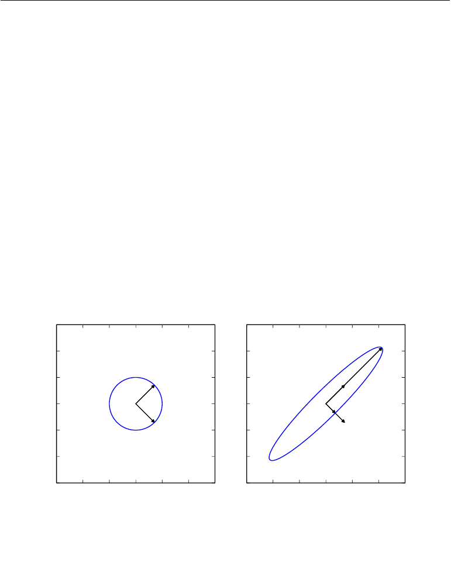

CHAPTER 2. LINEAR ALGEBRA

λ

n

]

. The eigendecomposition of A is then given by

A = V diag(λ)V

−1

. (2.40)

We have seen that constructing matrices with speciﬁc eigenvalues and eigen-

vectors enables us to stretch space in desired directions. Yet we often want to

decompose

matrices into their eigenvalues and eigenvectors. Doing so can help

us analyze certain properties of the matrix, much as decomposing an integer into

its prime factors can help us understand the behavior of that integer.

Not every matrix can be decomposed into eigenvalues and eigenvectors. In some

cases, the decomposition exists but involves complex rather than real numbers.

Fortunately, in this book, we usually need to decompose only a speciﬁc class of

Figure 2.3: An example of the eﬀect of eigenvectors and eigenvalues. Here, we have

a matrix

A

with two orthonormal eigenvectors,

v

(1)

with eigenvalue

λ

1

and

v

(2)

with

eigenvalue

λ

2

. (Left)We plot the set of all unit vectors

u ∈ R

2

as a unit circle. (Right)We

plot the set of all points

Au

. By observing the way that

A

distorts the unit circle, we

can see that it scales space in direction v

(i)

by λ

i

.

41

CHAPTER 2. LINEAR ALGEBRA

matrices that have a simple decomposition. Speciﬁcally, every real symmetric

matrix can be decomposed into an expression using only real-valued eigenvectors

and eigenvalues:

A = QΛQ

, (2.41)

where

Q

is an orthogonal matrix composed of eigenvectors of

A

, and

Λ

is a

diagonal matrix. The eigenvalue Λ

i,i

is associated with the eigenvector in column

i

of

Q

, denoted as

Q

:,i

. Because

Q

is an orthogonal matrix, we can think of

A

as

scaling space by λ

i

in direction v

(i)

. See ﬁgure 2.3 for an example.

While any real symmetric matrix

A

is guaranteed to have an eigendecomposi-

tion, the eigendecomposition may not be unique. If any two or more eigenvectors

share the same eigenvalue, then any set of orthogonal vectors lying in their span

are also eigenvectors with that eigenvalue, and we could equivalently choose a

Q

using those eigenvectors instead. By convention, we usually sort the entries of

Λ

in descending order. Under this convention, the eigendecomposition is unique only

if all the eigenvalues are unique.

The eigendecomposition of a matrix tells us many useful facts about the

matrix. The matrix is singular if and only if any of the eigenvalues are zero.

The eigendecomposition of a real symmetric matrix can also be used to optimize

quadratic expressions of the form

f

(

x

) =

x

Ax

subject to

||x||

2

= 1. Whenever

x

is equal to an eigenvector of

A

,

f

takes on the value of the corresponding eigenvalue.

The maximum value of

f

within the constraint region is the maximum eigenvalue

and its minimum value within the constraint region is the minimum eigenvalue.

A matrix whose eigenvalues are all positive is called

positive deﬁnite

. A

matrix whose eigenvalues are all positive or zero valued is called

positive semideﬁ-

nite

. Likewise, if all eigenvalues are negative, the matrix is

negative deﬁnite

, and

if all eigenvalues are negative or zero valued, it is

negative semideﬁnite

. Positive

semideﬁnite matrices are interesting because they guarantee that

∀x, x

Ax ≥

0.

Positive deﬁnite matrices additionally guarantee that x

Ax = 0 ⇒ x = 0.

2.8 Singular Value Decomposition

In section 2.7, we saw how to decompose a matrix into eigenvectors and eigenvalues.

The

singular value decomposition

(SVD) provides another way to factorize

a matrix, into

singular vectors

and

singular values

. The SVD enables us to

discover some of the same kind of information as the eigendecomposition reveals;

however, the SVD is more generally applicable. Every real matrix has a singular

value decomposition, but the same is not true of the eigenvalue decomposition.

42

CHAPTER 2. LINEAR ALGEBRA

For example, if a matrix is not square, the eigendecomposition is not deﬁned, and

we must use a singular value decomposition instead.

Recall that the eigendecomposition involves analyzing a matrix

A

to discover

a matrix

V

of eigenvectors and a vector of eigenvalues

λ

such that we can rewrite

A as

A = V diag(λ)V

−1

. (2.42)

The singular value decomposition is similar, except this time we will write

A

as a product of three matrices:

A = U DV

. (2.43)

Suppose that

A

is an

m ×n

matrix. Then

U

is deﬁned to be an

m ×m

matrix,

D to be an m × n matrix, and V to be an n × n matrix.

Each of these matrices is deﬁned to have a special structure. The matrices

U

and

V

are both deﬁned to be orthogonal matrices. The matrix

D

is deﬁned to be

a diagonal matrix. Note that D is not necessarily square.

The elements along the diagonal of

D

are known as the

singular values

of

the matrix

A

. The columns of

U

are known as the

left-singular vectors

. The

columns of V are known as as the right-singular vectors.

We can actually interpret the singular value decomposition of

A

in terms of

the eigendecomposition of functions of

A

. The left-singular vectors of

A

are the

eigenvectors of

AA

. The right-singular vectors of

A

are the eigenvectors of

A

A

.

The nonzero singular values of

A

are the square roots of the eigenvalues of

A

A

.

The same is true for AA

.

Perhaps the most useful feature of the SVD is that we can use it to partially

generalize matrix inversion to nonsquare matrices, as we will see in the next section.

2.9 The Moore-Penrose Pseudoinverse

Matrix inversion is not deﬁned for matrices that are not square. Suppose we want

to make a left-inverse B of a matrix A so that we can solve a linear equation

Ax = y (2.44)

by left-multiplying each side to obtain

x = By. (2.45)

43

[figure not shown]

CHAPTER 2. LINEAR ALGEBRA

Depending on the structure of the problem, it may not be possible to design a

unique mapping from A to B.

If

A

is taller than it is wide, then it is possible for this equation to have

no solution. If

A

is wider than it is tall, then there could be multiple possible

solutions.

The

Moore-Penrose pseudoinverse

enables us to make some headway in

these cases. The pseudoinverse of A is deﬁned as a matrix

A

+

= lim

α0

(A

A + αI)

−1

A

. (2.46)

Practical algorithms for computing the pseudoinverse are based not on this deﬁni-

tion, but rather on the formula

A

+

= V D

+

U

, (2.47)

where

U

,

D

and

V

are the singular value decomposition of

A

, and the pseudoinverse

D

+

of a diagonal matrix

D

is obtained by taking the reciprocal of its nonzero

elements then taking the transpose of the resulting matrix.

When

A

has more columns than rows, then solving a linear equation using the

pseudoinverse provides one of the many possible solutions. Speciﬁcally, it provides

the solution

x

=

A

+

y

with minimal Euclidean norm

||x||

2

among all possible

solutions.

When

A

has more rows than columns, it is possible for there to be no solution.

In this case, using the pseudoinverse gives us the

x

for which

Ax

is as close as

possible to y in terms of Euclidean norm ||Ax − y||

2

.

2.10 The Trace Operator

The trace operator gives the sum of all the diagonal entries of a matrix:

Tr(A) =

i

A

i,i

. (2.48)

The trace operator is useful for a variety of reasons. Some operations that are

diﬃcult to specify without resorting to summation notation can be speciﬁed using

matrix products and the trace operator. For example, the trace operator provides

an alternative way of writing the Frobenius norm of a matrix:

||A||

F

=

Tr(AA

). (2.49)

44

CHAPTER 2. LINEAR ALGEBRA

Writing an expression in terms of the trace operator opens up opportunities to

manipulate the expression using many useful identities. For example, the trace

operator is invariant to the transpose operator:

Tr(A) = Tr(A

). (2.50)

The trace of a square matrix composed of many factors is also invariant to

moving the last factor into the ﬁrst position, if the shapes of the corresponding

matrices allow the resulting product to be deﬁned:

Tr(ABC) = Tr(CAB) = Tr(BCA) (2.51)

or more generally,

Tr(

n

i=1

F

(i)

) = Tr(F

(n)

n−1

i=1

F

(i)

). (2.52)

This invariance to cyclic permutation holds even if the resulting product has a

diﬀerent shape. For example, for A ∈ R

m×n

and B ∈ R

n×m

, we have

Tr(AB) = Tr(BA) (2.53)

even though AB ∈ R

m×m

and BA ∈ R

n×n

.

Another useful fact to keep in mind is that a scalar is its own trace:

a

=

Tr

(

a

).

2.11 The Determinant

The determinant of a square matrix, denoted

det

(

A

), is a function that maps

matrices to real scalars. The determinant is equal to the product of all the

eigenvalues of the matrix. The absolute value of the determinant can be thought

of as a measure of how much multiplication by the matrix expands or contracts

space. If the determinant is 0, then space is contracted completely along at least

one dimension, causing it to lose all its volume. If the determinant is 1, then the

transformation preserves volume.

2.12 Example: Principal Components Analysis

One simple machine learning algorithm,

principal components analysis

(PCA),

can be derived using only knowledge of basic linear algebra.

45

CHAPTER 2. LINEAR ALGEBRA

Suppose we have a collection of m points {x

(1)

, . . . , x

(m)

} in R

n

and we want

to apply lossy compression to these points. Lossy compression means storing the

points in a way that requires less memory but may lose some precision. We want

to lose as little precision as possible.

One way we can encode these points is to represent a lower-dimensional version

of them. For each point

x

(i)

∈ R

n

we will ﬁnd a corresponding code vector

c

(i)

∈ R

l

.

If

l

is smaller than

n

, storing the code points will take less memory than storing the

original data. We will want to ﬁnd some encoding function that produces the code

for an input,

f

(

x

) =

c

, and a decoding function that produces the reconstructed

input given its code, x ≈ g(f (x)).

PCA is deﬁned by our choice of the decoding function. Speciﬁcally, to make the

decoder very simple, we choose to use matrix multiplication to map the code back

into R

n

. Let g(c) = Dc, where D ∈ R

n×l

is the matrix deﬁning the decoding.

Computing the optimal code for this decoder could be a diﬃcult problem. To

keep the encoding problem easy, PCA constrains the columns of

D

to be orthogonal

to each other. (Note that

D

is still not technically “an orthogonal matrix” unless

l = n.)

With the problem as described so far, many solutions are possible, because we

can increase the scale of

D

:,i

if we decrease

c

i

proportionally for all points. To give

the problem a unique solution, we constrain all the columns of

D

to have unit

norm.

In order to turn this basic idea into an algorithm we can implement, the ﬁrst

thing we need to do is ﬁgure out how to generate the optimal code point

c

∗

for

each input point

x

. One way to do this is to minimize the distance between the

input point

x

and its reconstruction,

g

(

c

∗

). We can measure this distance using a

norm. In the principal components algorithm, we use the L

2

norm:

c

∗

= arg min

c

||x − g(c)||

2

. (2.54)

We can switch to the squared

L

2

norm instead of using the

L

2

norm itself

because both are minimized by the same value of

c

. Both are minimized by the

same value of

c

because the

L

2

norm is non-negative and the squaring operation is

monotonically increasing for non-negative arguments.

c

∗

= arg min

c

||x − g(c)||

2

2

. (2.55)

The function being minimized simpliﬁes to

(x − g(c))

(x − g(c)) (2.56)

46

CHAPTER 2. LINEAR ALGEBRA

(by the deﬁnition of the L

2

norm, equation 2.30)

= x

x − x

g(c) −g(c)

x + g(c)

g(c) (2.57)

(by the distributive property)

= x

x − 2x

g(c) + g(c)

g(c) (2.58)

(because the scalar g(c)

x is equal to the transpose of itself).

We can now change the function being minimized again, to omit the ﬁrst term,

since this term does not depend on c:

c

∗

= arg min

c

−2x

g(c) + g(c)

g(c). (2.59)

To make further progress, we must substitute in the deﬁnition of g(c):

c

∗

= arg min

c

−2x

Dc + c

D

Dc (2.60)

= arg min

c

−2x

Dc + c

I

l

c (2.61)

(by the orthogonality and unit norm constraints on D)

= arg min

c

−2x

Dc + c

c. (2.62)

We can solve this optimization problem using vector calculus (see section 4.3 if

you do not know how to do this):

∇

c

(−2x

Dc + c

c) = 0 (2.63)

− 2D

x + 2c = 0 (2.64)

c = D

x. (2.65)

This makes the algorithm eﬃcient: we can optimally encode

x

using just a

matrix-vector operation. To encode a vector, we apply the encoder function

f(x) = D

x. (2.66)

Using a further matrix multiplication, we can also deﬁne the PCA reconstruction

operation:

r(x) = g (f (x)) = DD

x. (2.67)

47

[figure not shown]

CHAPTER 2. LINEAR ALGEBRA

Next, we need to choose the encoding matrix

D

. To do so, we revisit the idea

of minimizing the

L

2

distance between inputs and reconstructions. Since we will

use the same matrix

D

to decode all the points, we can no longer consider the

points in isolation. Instead, we must minimize the Frobenius norm of the matrix

of errors computed over all dimensions and all points:

D

∗

= arg min

D

i,j

x

(i)

j

− r(x

(i)

)

j

2

subject to D

D = I

l

. (2.68)

To derive the algorithm for ﬁnding

D

∗

, we start by considering the case where

l

= 1. In this case,

D

is just a single vector,

d

. Substituting equation 2.67 into

equation 2.68 and simplifying D into d, the problem reduces to

d

∗

= arg min

d

i

||x

(i)

− dd

x

(i)

||

2

2

subject to ||d||

2

= 1. (2.69)

The above formulation is the most direct way of performing the substitution but

is not the most stylistically pleasing way to write the equation. It places the scalar

value

d

x

(i)

on the right of the vector

d

. Scalar coeﬃcients are conventionally

written on the left of vector they operate on. We therefore usually write such a

formula as

d

∗

= arg min

d

i

||x

(i)

− d

x

(i)

d||

2

2

subject to ||d||

2

= 1, (2.70)

or, exploiting the fact that a scalar is its own transpose, as

d

∗

= arg min

d

i

||x

(i)

− x

(i)

dd||

2

2

subject to ||d||

2

= 1. (2.71)

The reader should aim to become familiar with such cosmetic rearrangements.

At this point, it can be helpful to rewrite the problem in terms of a single

design matrix of examples, rather than as a sum over separate example vectors.

This will enable us to use more compact notation. Let

X ∈ R

m×n

be the matrix

deﬁned by stacking all the vectors describing the points, such that

X

i,:

=

x

(i)

.

We can now rewrite the problem as

d

∗

= arg min

d

||X − Xdd

||

2

F

subject to d

d = 1. (2.72)

Disregarding the constraint for the moment, we can simplify the Frobenius norm

portion as follows:

arg min

d

||X − Xdd

||

2

F

(2.73)

48

CHAPTER 2. LINEAR ALGEBRA

= arg min

d

Tr

X − Xdd

X − Xdd

(2.74)

(by equation 2.49)

= arg min

d

Tr(X

X − X

Xdd

− dd

X

X + dd

X

Xdd

) (2.75)

= arg min

d

Tr(X

X) −Tr(X

Xdd

) − Tr(dd

X

X) + Tr(dd

X

Xdd

)

(2.76)

= arg min

d

−Tr(X

Xdd

) − Tr(dd

X

X) + Tr(dd

X

Xdd

) (2.77)

(because terms not involving d do not aﬀect the arg min)

= arg min

d

−2 Tr(X

Xdd

) + Tr(dd

X

Xdd

) (2.78)

(because we can cycle the order of the matrices inside a trace, equation 2.52)

= arg min

d

−2 Tr(X

Xdd

) + Tr(X

Xdd

dd

) (2.79)

(using the same property again).

At this point, we reintroduce the constraint:

arg min

d

−2 Tr(X

Xdd

) + Tr(X

Xdd

dd

) subject to d

d = 1 (2.80)

= arg min

d

−2 Tr(X

Xdd

) + Tr(X

Xdd

) subject to d

d = 1 (2.81)

(due to the constraint)

= arg min

d

−Tr(X

Xdd

) subject to d

d = 1 (2.82)

= arg max

d

Tr(X

Xdd

) subject to d

d = 1 (2.83)

= arg max

d

Tr(d

X

Xd) subject to d

d = 1. (2.84)

This optimization problem may be solved using eigendecomposition. Speciﬁcally,

the optimal

d

is given by the eigenvector of

X

X

corresponding to the largest

eigenvalue.

This derivation is speciﬁc to the case of

l

= 1 and recovers only the ﬁrst

principal component. More generally, when we wish to recover a basis of principal

49

CHAPTER 2. LINEAR ALGEBRA

components, the matrix

D

is given by the

l

eigenvectors corresponding to the

largest eigenvalues. This may be shown using proof by induction. We recommend

writing this proof as an exercise.

Linear algebra is one of the fundamental mathematical disciplines necessary to

understanding deep learning. Another key area of mathematics that is ubiquitous

in machine learning is probability theory, presented next.

50